```python
# This Python 3 environment comes with many helpful analytics libraries installed
# It is defined by the kaggle/python Docker image: https://github.com/kaggle/docker-python
# For example, here's several helpful packages to load

import numpy as np # linear algebra
from datetime import datetime, timedelta
import geopandas as gpd
import folium
import folium.plugins as plugins
import pandas as pd # data processing, CSV file I/O (e.g. pd.read_csv)
import matplotlib.pyplot as plt
import seaborn as sns
import re
from collections import defaultdict
import json
import requests
import base64
from dateutil import parser
from concurrent.futures import ThreadPoolExecutor, as_completed
from pandas.api.types import infer_dtype
import requests
import time
from folium.plugins import HeatMapWithTime
import datetime

# Input data files are available in the read-only "../input/" directory
# For example, running this (by clicking run or pressing Shift+Enter) will list all files under the input directory

import os
for dirname, _, filenames in os.walk('/kaggle/input/'):
    for filename in filenames:
        print(os.path.join(dirname, filename))

# You can write up to 20GB to the current directory (/kaggle/working/) that gets preserved as output when you create a version using "Save & Run All"
# You can also write temporary files to /kaggle/temp/, but they won't be saved outside of the current session

# File reads are handled uniformly by passing in a list of file paths, even for individual files
def read_files(file_paths):
    if isinstance(file_paths, str):
        file_paths = [file_paths]  # If file is a single string, convert it to a list
    dataframes = [] # The initialization list is used to store the DataFrame
    for path in file_paths:
        try:
            df = pd.read_csv(path, encoding='utf-8', low_memory=False)
            dataframes.append(df)
        except UnicodeDecodeError as e:
            print(f"Encoding error while reading {path}: {e}")
        except Exception as e:
            print(f"Error reading {path}: {e}")
    # Merge all DataFrame objects into a single DataFrame
    if dataframes:
        return pd.concat(dataframes, axis=0, ignore_index=True)
    else:
        return pd.DataFrame()  # If no data was successfully read, an empty DataFrame is returned.

# Extracts the year, month, day, hour, minute, and second.
def extract_datetime(df, time_column, level='second'):
    # extract the time component
    df['year'] = df[time_column].dt.year
    df['month'] = df[time_column].dt.month
    df['day'] = df[time_column].dt.day

    if level == 'hour' or level == 'second':
        df['hour'] = df[time_column].dt.hour
    if level == 'second':
        df['minute'] = df[time_column].dt.minute
        df['second'] = df[time_column].dt.second

    return df

# Gets the JSON data from the given URL and converts it into a Python dictionary.
def fetch_json_data(url):
    try:
        response = requests.get(url)
        response.raise_for_status()  # Triggers an exception if the response state is not 200
        return json.loads(response.text)  # Parses a JSON string into a dictionary
    except requests.RequestException as e:
        print(f"Request error: {e}")
    except json.JSONDecodeError as e:
        print(f"JSON decode error: {e}")

    return None

# Check if the index of the given DataFrame is continuous.
def is_index_continuous(df):
    """
    Returns:
    bool: True if the index is continuous, False otherwise.
    """
    return (df.index.to_series().diff().fillna(1) == 1).all()

# Combines the year, month, and date into a date-time object.
def combine_date_columns(df, year_col, month_col, day_col):
    """
    Return：
    A Series that contains a combined date-time object.
    """
    date = pd.to_datetime({'year': df[year_col], 'month': df[month_col], 'day': df[day_col]})
    return date
```

# 1 Motivation

Washington, D.C., is a quiet, uncluttered city. At sunset, take a walk in Washington Monument Square, dusk will surround the scenery rendered in a layer of hazy gold, lovers are holding hands, children are playing, vehicles are driving. As night falls, Washington's nightlife kicks off, and in the same time and space, the city's elegant and dignified daytime may be a quiet breeding ground for crime in some dark corners of the city at night...

If the streetlights in a city street malfunction, how does it affect the residents of the street at this very moment? Our attention was drawn to this by reading a predictive article about street lighting and crime rates: the author makes a bold prediction: 'Crime rates tend to fall when street lighting is damaged.' , a view that runs counter to our common sense: 'when streetlights are broken, crime rates predictably must rise', so we set out to analyse the current state of safety on Washington's city streets with this question in mind.

1. the street light distribution dataset in Washington DC
2. 311_City_Service_Requests (street light downtime reports) in Washington DC
3. Washington DC's Neighbourhood Crash Data Set
4. crime dataset for Washington DC

The statistics on the strength of street lighting in Washington's neighbourhoods, as well as the city's safety conditions during the hours of street light failures, give us a grasp of the importance of city lighting for resident safety and traffic safety. Good street lighting can significantly improve people's sense of safety at night. Adequately lit streetlights not only eliminate hidden dangers in the dark, but also effectively reduce crime rates, especially street crime such as theft and robbery. Residents feel safer as a result and are more likely to spend time outdoors at night. In addition, improved street lighting enhances the safety of vehicles and pedestrians at night. Quality lighting conditions help to reduce the number of traffic accidents by giving both motorists and pedestrians a clear view of the road and potential hazards. This not only ensures the safety of pedestrians, but also improves the overall smoothness of traffic flow, creating a safer and more livable urban environment.

# 2. Basic stats¶

In this section, we will describe the choices in data cleaning and preprocessing, and summarize the basic statistics and main visualizations from the exploratory data analysis (EDA) of the dataset.

## 2.1 Street Lights

The street light dataset, covering street lamps in operation from 2007 to 2023, can be accessed from the Open Data DC official platform. Each row of the dataset includes key parameters such as illumination intensity, lighting duration, and energy consumption. We have compiled these data into a dataframe named `df_street_lights`. The main attributes of the data are as follows:

- `X` : Indicates the longitude coordinate of the street light location (float64 type, exact floating point number).
- `Y` : Latitude coordinate (float64 type, exact floating point number) indicating the location of the street light.
- `CROSSSTREET` : The name of the intersection of the street (object type, usually refers to a string).
- `FACILITYID` : Facility number or identification of the street light (object type, usually a combination of string or number).
- `INOPERATION` : The time when the streetlight started operation, using the UTC time standard (datetime64[ns, UTC] type, datetime format with time zone).
- `QUADRANT_DESC` : Description of the city quadrant in which the streetlight is located (object type, e.g. NE, NW, SE, SW).
- `ROADCLASSIFICATION_DESC` : describes the type or classification of the street on which the streetlight is located (OBJECT type, e.g., major road, minor road, etc.).
- `STREETNAME` : The name of the street where the streetlight is located (object type, usually a string).
- `WARD` : the administrative district in which the streetlight is located, e.g., a ward in a city (float64 type, usually represents a non-contiguous categorical variable although it is a number).

```python
df_street_lights = read_files('/kaggle/input/street-lights/Street_Lights.csv')

na_patterns = r'(?i)^(n/a|na|nan|null|undefined|none)$|^$'
df_street_lights.replace(to_replace=na_patterns, value=np.nan, regex=True, inplace=True)

df_street_lights.replace(to_replace=[None], value=np.nan, inplace=True)

# Time type data conversion
datetime_columns = ['ADDTOGIS', 'INOPERATION', 'LASTMODIFIED', 'LASTPAINTED', 'LEDINOPERATION']

for column in datetime_columns:
    try:
        df_street_lights[column] = pd.to_datetime(df_street_lights[column], format='%Y/%m/%d %H:%M:%S%z')
    except ValueError:
        df_street_lights[column] = pd.to_datetime(df_street_lights[column], errors='coerce')
```

We identified a large number of missing fields in the 'INOPERATION' field in the street lights dataset. To address this, we filled in the missing dates with the GIS add date with the least amount of null data (`ADDTOGIS`) and ensured that it was earlier than or equal to the associated time field (`LASTMODIFIED`, `LASTPAINTED`, `LEDINOPERATION`). If `ADDTOGIS` satisfies the condition, use it to populate `INOPERATION`; if later than these dates, select the earliest date to populate.

```python
# If 'ADDTOGIS' is not the earliest, update 'INOPERATION' with the earliest of the other three time fields.
def fill_inoperation(row):
    addtogis = row['ADDTOGIS']
    inoperation = row['INOPERATION']
    lastmodified = row['LASTMODIFIED']
    lastpainted = row['LASTPAINTED']
    ledinoperation = row['LEDINOPERATION']

    # If INOPERATION already has a value, return it directly
    if not pd.isna(inoperation):
        return inoperation

    # Collect all dates and remove missing values
    dates = [addtogis, lastmodified, lastpainted, ledinoperation]
    dates = [date for date in dates if not pd.isna(date)]

    # If there is no valid date, the original null value is returned
    if not dates:
        return pd.NaT

    # Returns the earliest of all valid dates
    return min(dates)

df_street_lights['INOPERATION'] = df_street_lights.apply(fill_inoperation, axis=1)

# Extracts a subset of spatial and temporal columns to manage large datasets
df_street_lights = df_street_lights[["X", "Y", "CROSSSTREET", "FACILITYID", "INOPERATION", "QUADRANT_DESC", "ROADCLASSIFICATION_DESC", "STREETNAME", "WARD", "XCOORD", "YCOORD", "OBJECTID", "GLOBALID_1"]]

# Deleting data with null INOPERATION values
df_street_lights = df_street_lights.dropna(subset=['INOPERATION'])
df_street_lights = df_street_lights.reset_index(drop=True)

# Call the function to extract each time component
df_street_lights = extract_datetime(df_street_lights, 'INOPERATION', level='day')

# converts a floating-point number to an integer
df_street_lights['WARD'] = df_street_lights['WARD'].astype(int)
```

Check for suspicious minima by sorting the dataset using the `INOPERATION` date column. we found the date January 1, 1970. It is usually implausible because it may have been set by default due to a lack of information about the true date. Therefore, this data set should be considered an outlier or invalid.

```python
# Check the mimimum values to see if there are any suspicious-looking, 70s dates
df_street_lights.sort_values("INOPERATION").head()
```

```python
df_street_lights = df_street_lights[df_street_lights['INOPERATION'] != '1970-01-01 20:45:00+00:00']
```

Missing street names were filled in through geocoding services, and these names were normalized through character capitalization, removal of redundant spaces, and replacement of abbreviations. In addition, we filled in the missing values of the road classification descriptions through statistical analysis and addressed the missing cross-street information through geographic sorting and before-and-after filling methods.

```python
# Complete the name of the street
df_no_streetname = df_street_lights[df_street_lights['STREETNAME'].isnull()]

# The geocoding service is invoked using longitude and latitude data
mar_api_key = '7b6e7270-1c2f-4bfc-839a-3c025653e043'

baseurl = "https://datagate.dc.gov/mar/open/api/v2.2/locations/"

for index, row in df_no_streetname.iterrows():
    lng = row['X']
    lat = row['Y']

    mar_url = f"{baseurl}{lng},{lat}?apikey={mar_api_key}"

    response = requests.get(mar_url)

    if response.status_code == 200:
        data = response.json()
        if 'Result' in data and len(data['Result']) > 0:
            df_street_lights.at[index, 'STREETNAME'] = data['Result'][0]['address']['properties']['FullAddress']
        else:
            print(f"No results found for {lng}, {lat}")

    else:
        print(f"Failed to geocode {lng}, {lat}: {response.status_code}")

# Standardize street names and classifications
df_street_lights['STREETNAME'] = df_street_lights['STREETNAME'].str.upper()
df_street_lights['STREETNAME'] = df_street_lights['STREETNAME'].str.strip()
df_street_lights['STREETNAME'] = df_street_lights['STREETNAME'].str.replace(r'\s+', ' ', regex=True)
df_street_lights['STREETNAME'] = df_street_lights['STREETNAME'].str.replace(r'[^\w\s-]', '', regex=True)
df_street_lights['STREETNAME'] = df_street_lights['STREETNAME'].apply(lambda x: re.sub(r'(?i)(\d+)\s+(th|nd)', r'\1\2', x))

replacements = {
    r'\bST\b': 'STREET',
    r'\bRD\b': 'ROAD',
    r'\bAVE\b': 'AVENUE',
    r'\bBLVD\b': 'BOULEVARD',
    r'\bDR\b': 'DRIVE',
    r'\bPL\b': 'PLACE',
    r'\bLN\b': 'LANE',
    r'\bTER\b': 'TERRACE',
    r'\bSQ\b': 'SQUARE',
    r'\bCT\b': 'COURT',
    r'\bCIR\b': 'CIRCLE',
    r'\bPKWY\b': 'PARKWAY',
    r'\bNW\b': 'NORTHWEST',
    r'\bNE\b': 'NORTHEAST',
    r'\bSW\b': 'SOUTHWEST',
    r'\bSE\b': 'SOUTHEAST'
}

for old, new in replacements.items():
    df_street_lights['STREETNAME'] = df_street_lights['STREETNAME'].str.replace(old, new, regex=True)
    df_street_lights['CROSSSTREET'] = df_street_lights['CROSSSTREET'].str.replace(old, new, regex=True)
    df_street_lights['QUADRANT_DESC'] = df_street_lights['QUADRANT_DESC'].str.replace(old, new, regex=True)

df_street_lights['ROADCLASSIFICATION_DESC'] = df_street_lights['ROADCLASSIFICATION_DESC'].str.upper()

most_common = df_street_lights.groupby('STREETNAME')['ROADCLASSIFICATION_DESC'].transform(lambda x: x.mode()[0] if not x.mode().empty else None)
df_street_lights['ROADCLASSIFICATION_DESC'] = df_street_lights['ROADCLASSIFICATION_DESC'].fillna(most_common)

# Locate the row whose section is described as None
rows_with_none_description = df_street_lights[df_street_lights['ROADCLASSIFICATION_DESC'].isnull()]

# print("The street name value of the row whose segment is described as None：")
# print(rows_with_none_description['STREETNAME'].unique())

# Process Cross Street information
# Create a mapping dictionary that maps old values to new values
replacement_map = {
    '2200 SOUTH CAPITOL STREET SOUTHEAST': 'SOUTH CAPITOL STREET',
    '1625 SOUTH CAPITOL STREET SOUTHWEST': 'SOUTH CAPITOL STREET',
    '1620 SOUTH CAPITOL STREET SOUTHEAST': 'SOUTH CAPITOL STREET',
    '1601 SOUTH CAPITOL STREET SOUTHWEST': 'SOUTH CAPITOL STREET',
    '1515 SOUTH CAPITOL STREET SOUTHWEST': 'SOUTH CAPITOL STREET',
    '10TH STREET NORTHWEST': '10TH STREET',
    '3900 WISCONSIN AVENUE NORTHWEST': 'WISCONSIN AVENUE',
    'NEVEDA AVENUE': 'NEVADA AVENUE'
}

# Use the map method to replace the value of the street name of the row whose segment is described as None
df_street_lights.loc[df_street_lights['ROADCLASSIFICATION_DESC'].isnull(), 'STREETNAME'] = df_street_lights.loc[df_street_lights['ROADCLASSIFICATION_DESC'].isnull(), 'STREETNAME'].map(replacement_map)

most_common = df_street_lights.groupby('STREETNAME')['ROADCLASSIFICATION_DESC'].transform(lambda x: x.mode()[0] if not x.mode().empty else None)
df_street_lights['ROADCLASSIFICATION_DESC'] = df_street_lights['ROADCLASSIFICATION_DESC'].fillna(most_common)

# Sort by latitude and longitude to ensure geographical proximity
df_street_lights.sort_values(by=['Y', 'X'], inplace=True)
df_street_lights = df_street_lights.reset_index(drop=True)

df_street_lights['CROSSSTREET'] = df_street_lights['CROSSSTREET'].ffill()
df_street_lights['CROSSSTREET'] = df_street_lights['CROSSSTREET'].bfill()

# Sort by time column
df_street_lights = df_street_lights.sort_values(by='INOPERATION')
df_street_lights.reset_index(drop=True, inplace=True)
```

As mentioned earlier, we found a large number of missing time values in the `INOPERATION` field in our dataset, while in contrast, the time values in the `ADDTOGIS` field were intact. While we have adopted a strategy to deal with this missing data, we need to dig deeper to find out why this missing data is occurring - this can help determine if the missing values are significant or meaningful.

```python
# street_light_in_DC
layer = pdk.Layer(
    'ScatterplotLayer',
    df_street_lights,
    auto_highlight=True,
    pickable=True,
    get_position=['X', 'Y'],
    get_fill_color=[255, 255, 255, 255],
    get_line_color=[255, 255, 255, 40],
    get_radius=5,  # 半径大小
    line_width_min_pixels=3,
    stroked=True
)

view_state = pdk.ViewState(
    latitude=df_street_lights['Y'].mean(),
    longitude=df_street_lights['X'].mean(),
    zoom=15,
    pitch=40.5,
    bearing=-27.36
)

deck = pdk.Deck(layers=[layer], initial_view_state=view_state)

display(deck.show())
```

### 2.1.1 The Golden Age of Illumination

With 5 years of rapid growth in Washington, D.C., how has the infrastructure kept up? Now let's explore and reveal which year the city peaked in streetlight construction.

```python
annual_street_lights = df_street_lights.groupby('year').size()
annual_street_lights_df = annual_street_lights.reset_index(name='number_of_streetlights')

fig = px.bar(annual_street_lights_df, x="year", y="number_of_streetlights", height=500)
fig.show()
```

While 2007 may not have been the golden age of lighting in Washington, D.C., it was the year's data aggregation that set the stage for the region's booming growth. By consolidating and updating street lighting data, Washington, D.C. was able to plan and improve its urban infrastructure more efficiently, which in turn supported subsequent rapid development and city beautification projects.

尽管2007年可能并不是华盛顿特区照明的黄金时期，但正是这一年的数据汇总为该地区的繁荣发展奠定了基础。通过整合和更新路灯数据，华盛顿特区得以更有效地规划和改进其城市基础设施，从而支持了后续的快速发展和城市美化项目。

### 2.1.2 Where the Lights Are?

Lighting is not only about aesthetics, but also about safety and comfortable living. We will compare the distribution of streetlights in each area and analyze why some areas have a particularly high density of streetlights while others have relatively few, and whether this is related to the size of the area or population density.

```python
df_street_lights_group = df_street_lights.groupby(['WARD', 'year']).size().unstack(fill_value=0)
df_street_lights_group['Total'] = df_street_lights_group.sum(axis=1)
df_street_lights_group
```

After that, we found the area and population density of the districts of Washington, D.C. through Census Reporter. These data were combined with data on streetlights in each district to make a new table, and its correlation between district area, population density, and streetlight density was analyzed.

```python
ward_counts = df_street_lights.groupby('WARD').size()

ward_counts_df = ward_counts.reset_index(name='Light Count')


dc_wards = {
    1: {"Area (sq mi)": 2.2, "Population Density (per sq mi)": 38621},

    2: {"Area (sq mi)": 7.9, "Population Density (per sq mi)": 8936},

    3: {"Area (sq mi)": 9.1, "Population Density (per sq mi)": 6664},

    4: {"Area (sq mi)": 7.0, "Population Density (per sq mi)": 10888},

    5: {"Area (sq mi)": 7.2, "Population Density (per sq mi)": 10124},

    6: {"Area (sq mi)": 6.7, "Population Density (per sq mi)": 15545},

    7: {"Area (sq mi)": 12.4, "Population Density (per sq mi)": 4646},

    8: {"Area (sq mi)": 16.6, "Population Density (per sq mi)": 3526}

}

# Convert dc_wards to DataFrame
dc_wards = pd.DataFrame.from_dict(dc_wards, orient='index').reset_index()

dc_wards.rename(columns={'index': 'WARD'}, inplace=True)


dc_wards_combined_df = pd.merge(dc_wards, ward_counts_df, on='WARD')
dc_wards_combined_df['Streetlight Density'] = dc_wards_combined_df['Light Count'] / dc_wards_combined_df['Area (sq mi)']
dc_wards_combined_df[['Area (sq mi)', 'Population Density (per sq mi)', 'Streetlight Density']]
```

```python
# Correlation analysis
correlation_matrix = dc_wards_combined_df[['Streetlight Density', 'Population Density (per sq mi)', 'Area (sq mi)']].corr()
correlation_matrix
```

The correlation analysis revealed a strong positive correlation between streetlight density and population density, indicating that more densely populated areas in Washington, D.C. typically have more streetlights, while a strong negative correlation with area size indicated that larger areas have fewer streetlights per square mile. This may be due to the fact that larger areas have more diverse land uses, including areas that do not require intense street lighting, such as parks, industrial areas, or undeveloped land. There is also a negative correlation between population density and area size, suggesting that larger areas tend to be less populated.

Based on these findings, it can be hypothesized that Washington, D.C.'s needs to consider a variety of factors, such as regional foot traffic, safety needs, and infrastructure needs in newly developed areas, when conducting urban planning for the deployment of street lighting.

### 2.1.3 The Main Path Illuminated

The type of road determines the frequency and importance of its use, and the distribution of streetlights varies on different types of roads. We explore whether all main roads are adequately illuminated.

The city's road network consists of a variety of road types, which generally relate to each other and their number as follows:

- Local: Local roads are usually the most numerous and are located at every corner, providing basic connections to residential and commercial areas.
- Collector: Collector roads are more numerous and direct traffic from local roads to arterials.
- Minor Arterial: Minor arterials are relatively few in number, but are still more numerous than major arterials and highways. They connect small towns or different parts of the city and provide faster access.
- Principal Arterial: Fewer in number than secondary arterials, principal arterials carry high-capacity traffic and usually connect important commercial and industrial centers and cities.
- Other Freeway and Expressway: Freeway and expressways designed for high speed and high volume traffic, connecting large cities and important locations, limited in number but with wide coverage and high serviceability.
- Interstate: Although the fewest in number, interstate highways are key roadways connecting major cities and regions across the country.

```python
road_street_lights = df_street_lights.groupby('ROADCLASSIFICATION_DESC').size()
road_street_lights_df = road_street_lights.reset_index(name='number_of_streetlights')

road_street_lights_df = road_street_lights_df.sort_values('number_of_streetlights', ascending=False)

fig = px.bar(road_street_lights_df, x="ROADCLASSIFICATION_DESC", y="number_of_streetlights", height=500)
fig.show()
```

This may be due to the important role of minor arterials in the urban transportation system. For example, they are used to connect different parts of the city and may serve higher volumes and more commuters. Therefore, in order to improve the safety and visibility of these roadways, it may be necessary to install more streetlights on secondary arterials to ensure nighttime safety and continuity of activity in the area. It also suggests that city planners need to consider lighting improvements on collector roads.

## 2.2 311 City Service Requests

All data comes from Open data DC. We obtained the 311 service request data from 2019 to 2023 and downloaded it in csv format. First, we read and merge the data sets of five years, and then select the data columns we need. The specific data attributes are as follows:

- `X`:Longitude
- `Y`:Latitude
- `OBJECTID`
- `SERVICECODE`: service code
- `SERVICECODEDESCRIPTION`: Service code description
- `SERVICETYPECODEDESCRIPTION`: Service type code description
- `ORGANIZATIONACRONYM`: Organization abbreviation
- `SERVICECALLCOUNT`: Service call count
- `ADDDATE`: Add date
- `RESOLUTIONDATE`: Resolution date
- `SERVICEDUEDATE`: Service expiration date
- `SERVICEORDERDATE`: Service order date
- `INSPECTIONDATE`: Inspection date
- `SERVICEORDERSTATUS`: Service order status
- `SERVICEREQUESTID`: Service request ID
- `PRIORITY`: priorities
- `STREETADDRESS`: Street address
- `LATITUDE`:
- `LONGITUDE`:
- `CITY`:
- `STATE`:
- `ZIPCODE`:
- `MARADDRESSREPOSITORYID`:
- `WARD`:
- `GLOBALID`:
- `year`:
- `month`:
- `day`:
- `hour`:
- `minute`:

Then we filter all "Street Light Repair Investigation" data in SERVICE CODE DESCRIPTION, then modify ADDDATE to python format and add year, month, day, hour and minute to store the data.In the graph made using XY, we found that there are gaps or small amounts of data in some areas. We originally thought this was a missing piece of data or an anomaly. After comparing the map of Washington, we found that the blank spots are parks, lakes and other places on the map. There are indeed no street lights, and there is no street light repair service. Finally we export the new data as our dataset

```python
file_path = ["/kaggle/input/311-city-service-requests/311_City_Service_Requests_in_2019.csv", "/kaggle/input/311-city-service-requests/311_City_Service_Requests_in_2020.csv", "/kaggle/input/311-city-service-requests/311_City_Service_Requests_in_2021.csv", "/kaggle/input/311-city-service-requests/311_City_Service_Requests_in_2022.csv", "/kaggle/input/311-city-service-requests/311_City_Service_Requests_in_2023.csv"]
df_311_city_service_requests = read_files(file_path)

df_311_city_service_requests.drop(columns=['CREATOR', 'CREATED', 'EDITOR', 'EDITED', 'INSPECTIONDATE', 'STATUS_CODE', 'DETAILS', 'GIS_ID', 'INSPECTIONFLAG', 'INSPECTORNAME'], inplace=True)

df_311_city_service_requests = df_311_city_service_requests.loc[df_311_city_service_requests['SERVICECODEDESCRIPTION'] == 'Streetlight Repair Investigation']
df_311_city_service_requests = df_311_city_service_requests.reset_index(drop=True)

df_311_city_service_requests['ADDDATE'] = pd.to_datetime(df_311_city_service_requests['ADDDATE'])
df_311_city_service_requests['year'] = df_311_city_service_requests['ADDDATE'].dt.year
df_311_city_service_requests['month'] = df_311_city_service_requests['ADDDATE'].dt.month
df_311_city_service_requests['day'] = df_311_city_service_requests['ADDDATE'].dt.day
df_311_city_service_requests['hour'] = df_311_city_service_requests['ADDDATE'].dt.hour
df_311_city_service_requests['minute'] = df_311_city_service_requests['ADDDATE'].dt.minute
df_311_city_service_requests['second'] = df_311_city_service_requests['ADDDATE'].dt.second
```

```python
# df_311_city_service_requests.to_csv('311_City_Service_Requests_Clean.csv',index=False, encoding='utf-8')
```

```python
df_311_city_service_requests.head()
```

```python
df_311_city_service_requests.info()
```

```python
df_311_city_service_requests['X'].plot(kind='line', figsize=(8, 4), title='X')
plt.gca().spines[['top', 'right']].set_visible(False)
```

```python
df_311_city_service_requests.plot(kind='scatter', x='X', y='Y', s=32, alpha=.8)
plt.gca().spines[['top', 'right',]].set_visible(False)
```

## 2.3 Crime Incidents

We obtained a dataset from the official Open Data Washington platform that records crime incidents occurring from 2019 through 2023 (with crime report data for a small portion of the time from 2018 through 2024). Each record contains key information such as the type of crime and when and where the incident occurred. These data are aggregated into a data framework called `df_crime_incidents`.

While cleaning and preprocessing the dataset, we found that some of the time columns `REPORT_DATE` , `START_DATE` and `END_DATE` in the wrong order: in general, `START_DATE` < `END_DATE` < `REPORT_DATE`. However, in some cases, incidents may be formally logged or reported long after the fact, especially when it comes to non emergency response types of crimes. Additionally, a chronological error may occur if `END_DATE` is the date that the end of the event was observed rather than the actual end date.

```python
file_path = ["../Input/Crime_Incidents/Crime_Incidents_in_2018.csv", "../Input/Crime_Incidents/Crime_Incidents_in_2019.csv", "../Input/Crime_Incidents/Crime_Incidents_in_2020.csv", "../Input/Crime_Incidents/Crime_Incidents_in_2021.csv", "../Input/Crime_Incidents/Crime_Incidents_in_2022.csv", "../Input/Crime_Incidents/Crime_Incidents_in_2023.csv", "../Input/Crime_Incidents/Crime_Incidents_in_2024.csv"]

df_crime_incidents = read_files(file_path)

na_patterns = r'(?i)^(n/a|na|nan|null|undefined|none)$|^$'

df_crime_incidents.replace(to_replace=na_patterns, value=np.nan, regex=True, inplace=True)

df_crime_incidents.rename(columns={'REPORT_DAT': 'REPORT_DATE'}, inplace=True)

df_crime_incidents['REPORT_DATE'] = pd.to_datetime(df_crime_incidents['REPORT_DATE'])

df_crime_incidents['START_DATE'] = pd.to_datetime(df_crime_incidents['START_DATE'])

df_crime_incidents['END_DATE'] = pd.to_datetime(df_crime_incidents['END_DATE'])

# Check for illogical date order
invalid_dates = df_crime_incidents[(df_crime_incidents['START_DATE'] > df_crime_incidents['REPORT_DATE']) | (df_crime_incidents['END_DATE'] > df_crime_incidents['REPORT_DATE'])]

print("Number of invalid date entries:", invalid_dates.shape[0])
```

Missing `START_DATE` and `END_DATE` collation time-related data were filled in by calculating durations and reporting delays. Afterwards, the data was pre-processed by sorting by date, filtering for specific time ranges and resetting indexes.

```python
# Only missing rows for END_DATE
# Compute the time difference.
df_crime_incidents['DURATION'] = (df_crime_incidents['END_DATE'] - df_crime_incidents['START_DATE']).dt.total_seconds()

# Calculate the median time difference grouped by crime type
median_durations = df_crime_incidents.groupby('OFFENSE')['DURATION'].median()

# Filter out records with START_DATE but not END_DATE
missing_end_dates = df_crime_incidents[(df_crime_incidents['START_DATE'].notnull()) & (df_crime_incidents['END_DATE'].isnull())]

# Estimate using START_DATE plus the average duration of the corresponding crime type END_DATE
for index, row in missing_end_dates.iterrows():
    crime_type = row['OFFENSE']
    median_duration = median_durations.get(crime_type, pd.Timedelta(seconds=0))  # The default value is 0
    estimated_end_date = row['START_DATE'] + pd.Timedelta(seconds=median_duration)
    df_crime_incidents.at[index, 'END_DATE'] = estimated_end_date

# missing rows for START_DATE and END_DATE
# Calculate the time difference between REPORT_DATE and START_DATE and END_DATE
df_crime_incidents['START_DELAY'] = (df_crime_incidents['REPORT_DATE'] - df_crime_incidents['START_DATE']).dt.total_seconds()
df_crime_incidents['END_DELAY'] = (df_crime_incidents['REPORT_DATE'] - df_crime_incidents['END_DATE']).dt.total_seconds()

# Calculate the median time difference based on the type of crime
median_start_delay = df_crime_incidents.groupby('OFFENSE')['START_DELAY'].median()
median_end_delay = df_crime_incidents.groupby('OFFENSE')['END_DELAY'].median()

# Fill START_DATE with median
for crime_type, delay in median_start_delay.items():
    mask = (df_crime_incidents['OFFENSE'] == crime_type) & (df_crime_incidents['START_DATE'].isnull())
    df_crime_incidents.loc[mask, 'START_DATE'] = df_crime_incidents.loc[mask, 'REPORT_DATE'] - pd.to_timedelta(delay, unit='s')

# Fill with median END_DATE
for crime_type, delay in median_end_delay.items():
    mask = (df_crime_incidents['OFFENSE'] == crime_type) & (df_crime_incidents['END_DATE'].isnull())
    df_crime_incidents.loc[mask, 'END_DATE'] = df_crime_incidents.loc[mask, 'REPORT_DATE'] - pd.to_timedelta(delay, unit='s')

# Fill null values in DURATION, START_DELAY, and END_DELAY columns
# Calculates DURATION if there is a null value
if df_crime_incidents['DURATION'].isnull().any():
    df_crime_incidents['DURATION'] = (df_crime_incidents['END_DATE'] - df_crime_incidents['START_DATE']).dt.total_seconds()

# Calculate START_DELAY if there is a null value
if df_crime_incidents['START_DELAY'].isnull().any():
    df_crime_incidents['START_DELAY'] = (df_crime_incidents['REPORT_DATE'] - df_crime_incidents['START_DATE']).dt.total_seconds()

# Calculates END_DELAY if there is a null value
if df_crime_incidents['END_DELAY'].isnull().any():
    df_crime_incidents['END_DELAY'] = (df_crime_incidents['REPORT_DATE'] - df_crime_incidents['END_DATE']).dt.total_seconds()

df_crime_incidents = df_crime_incidents.sort_values(by='START_DATE', ascending=True)

df_crime_incidents = df_crime_incidents[(df_crime_incidents['START_DATE'] >= '2019-01-01 00:00:00+00:00') & (df_crime_incidents['START_DATE'] <= '2023-12-31 23:59:59+00:00')]

df_crime_incidents.reset_index(drop=True, inplace=True)
```

In terms of processing geolocation information about the dataset, a spatial index (cKDTree) was constructed using the residual data, which facilitates nearest-neighbor searches for missing geographic fields and fills in null values.

```python
# Make sure that the latitude and longitude columns have no NaN values
df_crime_incidents = df_crime_incidents.dropna(subset=['Y', 'X'])

# Build a spatial index
coordinates = df_crime_incidents[['Y', 'X']].dropna().values
tree = cKDTree(coordinates)

# For each geographic field with a null value, do a nearest neighbor query and padding
geographic_columns = ['WARD', 'ANC', 'DISTRICT', 'PSA', 'NEIGHBORHOOD_CLUSTER', 'BLOCK_GROUP', 'CENSUS_TRACT', 'VOTING_PRECINCT']

for column in geographic_columns:
    mask = df_crime_incidents[column].isna()
    if mask.any():
        query_coords = df_crime_incidents.loc[mask, ['Y', 'X']].values
        _, idx = tree.query(query_coords, k=1)
        df_crime_incidents.loc[mask, column] = df_crime_incidents.loc[idx, column].values

df_crime_incidents = df_crime_incidents.drop(['BID', 'LATITUDE', 'LONGITUDE', 'OCTO_RECORD_ID'], axis=1)

df_crime_incidents_y = df_crime_incidents['Y'].tolist()
df_crime_incidents_x = df_crime_incidents['X'].tolist()
locations = list(zip(df_crime_incidents_y, df_crime_incidents_x))

map = folium.Map(
    location=[df_crime_incidents['Y'].mean(), df_crime_incidents['X'].mean()],
    zoom_start=12
)

FastMarkerCluster(data=locations).add_to(map)

map
```

### 2.3.1 When Silence Speaks?

When dealing with cases, victims often delay reporting to the police due to a variety of psychological and social factors. Such delays not only affect the efficiency of case detection, but may also exacerbate the victim's psychological trauma. We explored the phenomenon of delay in reporting to the police in cases through data analysis to understand the possible causes of the delay.

```python
median_end_delay_hours = median_end_delay / 3600

# 将Series转换为DataFrame
df_median_end_delay_hours = median_end_delay_hours.to_frame(name='Median Delay (hours)')


# 重置索引以使原索引成为一列
df_median_end_delay_hours.reset_index(inplace=True)


# 可以重命名列以更清晰地表示数据
df_median_end_delay_hours.columns = ['Offense Type', 'Median Delay (hours)']

# 使用plotly.express创建条形图
fig = px.bar(
    df_median_end_delay_hours,
    y='Offense Type',
    x='Median Delay (hours)',
    orientation='h',  # 水平条形图
    color='Offense Type',  # 按犯罪类型着色
    color_discrete_sequence=px.colors.sequential.Viridis  # 使用Viridis颜色序列
)

# 设置图表标题
fig.update_layout(
    title='Median Report Delay by Crime Type (in hours)',
    xaxis_title='Median Delay (hours)',
    yaxis_title='Offense Type'
)

# 显示图形
fig.show()
```

When we analyzed the collated data set, we found that in many of the “Homicide” type crimes, the report date (`REPORT_DATE`) was actually earlier than the start date (`START_DATE`) and the end date (`END_DATE`) of the case.

This phenomenon may not only be due to the automatic recording of time by technical systems, but may also involve a problem with the definition of events. Often, the start and end times of an incident are determined based on subsequent investigations, while the initial reporting date is based on the information initially received. In addition, the police may pre-record information based on a number of indications or threats, which is particularly common where a potential murder threat or other serious crime is involved. In addition, delayed reporting of witnesses or relevant information may also result in a report date earlier than the actual date of the incident.

```python
# Screen for HOMICIDE-type criminal records
homicide_records = df_crime_incidents[df_crime_incidents['OFFENSE'] == 'HOMICIDE']

# Select a specific column
homicide_dates = homicide_records[['REPORT_DATE', 'START_DATE', 'END_DATE', 'DURATION', 'START_DELAY', 'END_DELAY']].reset_index(drop=True)

homicide_dates.head()
```

In addition to this, victims of sexual assault will report the incident on average about a week after it occurs. We believe this is due to trauma, fear reactions, social and cultural pressures, and ignorance of legal and medical resources. Victims may need time to process complex emotions and fear social condemnation, which together often cause them to delay seeking help. Providing a supportive and non-judgmental environment is therefore essential to help victims report crimes in a timely manner.

### 2.3.2 Traces of Time

Crimes do not occur randomly, and their spatial and temporal patterns reveal underlying social and environmental factors. We analyzed the timing of different types of crimes over the course of a year, using time series analysis to explore long-term trends in criminal activity over time.

By analyzing the environment, climate, and geographic location, we believe that as the weather turns colder in November, people spend more time indoors, reducing the opportunity for arson; this time of year is the month of important holidays such as Thanksgiving, and people are more focused on family and community activities, which may result in fewer crimes. In addition, due to the small number of arsons overall, their monthly distribution may indicate statistical chance; errors or omissions in data collection or reporting cannot be ruled out.

```python
df_crime_incidents['START_DATE_MONTH'] = df_crime_incidents['START_DATE'].dt.month
df_crime_incidents_month = df_crime_incidents.groupby(['START_DATE_MONTH', 'OFFENSE']).size().reset_index(name='Count')

fig = go.Figure(data=go.Heatmap(
    z=df_crime_incidents_month['Count'],
    x=df_crime_incidents_month['START_DATE_MONTH'],
    y=df_crime_incidents_month['OFFENSE'],
    colorscale='Viridis',
     hovertemplate=
    'Month: %{x}<br>' +
    'Offense: %{y}<br>' +
    'Count: %{z}<extra></extra>',
))
fig.update_layout(title='Crime Incidents by Month and Offense Type', xaxis_nticks=12, height=500)
fig.update_xaxes(title='Month')
fig.show()
```

In contrast, the increase in thefts during the fall months of August through October may be attributed to the increased number of travelers who may be more susceptible to being targeted for crime due to the increased number of travelers during this time of peak tourism and the end of school vacations. The start of school and fall events, such as Halloween, may also increase theft opportunities. And the weather during these months is favorable for being outside, leading to more unattended property.

```python
# Create a line plot for each crime type
fig = px.line(df_crime_incidents_month,
              x='START_DATE_MONTH', y='Count', color='OFFENSE',
              height=500,
              line_shape='spline',  # Adding spline to smooth lines
              title='Monthly Crime Trends by Type',
              labels={'START_DATE_MONTH': 'Month', 'Count': 'Number of Incidents', 'OFFENSE': 'Offense'},
              category_orders={'START_DATE_MONTH': [str(m) for m in range(1, 13)]})  # Ensuring month order from 1 to 12

fig.update_layout(legend_title_text='Crime Type')
fig.show()
```

## 2.4 Crashes in DC

In the initial phase of the study, we obtained crash data covering Washington, D.C., from 2000 to 2023 through Open data DC. The raw data is downloaded as a CSV file, which contains key crash parameters such as time, crash type, casualty type, number of casualties, etc. Specific parameter information is as follows:

- `X`:Longitude 77.013222 degrees west longitude
- `Y`:Latitude 38.913611 degrees north latitude

  Washington, District of Columbia is located in the mid-Atlantic coast of the United States, at 38.913611 degrees north latitude and 77.013222 degrees west longitude.
- `REPORTDATE`: Report the date of the crash.
- `WARD`:DC Ward text value containing the center point of this segment. "99" indicates that the area is outside of DC. "Null" indicates a geometric error.
- `MAJORINJURIES_BICYCLIST`: Number of seriously injured cyclists.
- `MINORINJURIES_BICYCLIST`: Number of cyclists with minor injuries.
- `UNKNOWNINJURIES_BICYCLIST`:Number of cyclists with unknown injuries.
- `FATAL_BICYCLIST`: Cyclist fatalities.
- `MAJORINJURIES_DRIVER`: Number of seriously injured drivers.
- `MINORINJURIES_DRIVER`: Number of drivers with minor injuries.
- `UNKNOWNINJURIES_DRIVER`: Number of drivers with unknown injuries.
- `FATAL_DRIVER`: Driver fatalities.
- `MAJORINJURIES_PEDESTRIAN`: Number of pedestrians seriously injured.
- `MINORINJURIES_PEDESTRIAN`: Number of pedestrians with minor injuries.
- `UNKNOWNINJURIES_PEDESTRIAN`: Number of pedestrians with unknown injuries.
- `FATAL_PEDESTRIAN`: Pedestrian fatalities.
- `TOTAL_VEHICLES`: The total number of vehicles involved in the accident.
- `TOTAL_BICYCLES`: The total number of bicycles involved in the accident.
- `TOTAL_PEDESTRIANS`: The total number of pedestrians involved in the accident.
- `PEDESTRIANSIMPAIRED`: The total number of pedestrians affected in the accident.
- `BICYCLISTSIMPAIRED`: Total number of cyclists injured in accidents.
- `DRIVERSIMPAIRED`: The total number of drivers affected in the accident.
- `TOTAL_TAXIS`: The total number of taxis involved in the accident.
- `TOTAL_GOVERNMENT`: Total number of government vehicles involved in accidents.
- `SPEEDING_INVOLVED`: Was speeding involved in the crash?
- `NEARESTINTROUTEID`: intersection at nearest intersection RouteID。
- `NEARESTINTSTREETNAME`: The cross street name of the nearest intersection.
- `OFFINTERSECTION`: Distance from intersection center (meters).
- `INTAPPROACHDIRECTION`: The direction (north, south, east, west) of the intersection segment from the intersection.
- `FATALPASSENGER`: Passenger fatalities.
- `MAJORINJURIESPASSENGER`: Number of seriously injured passengers.
- `MINORINJURIESPASSENGER`: Number of passengers with minor injuries.
- `UNKNOWNINJURIESPASSENGER`: The number of injured passengers is unknown.

  We then process this data into a data set called data, where each row represents a separate record containing date, location, time, type of car accident, and number of casualties. During the data cleaning phase, we deleted most of the data related to professional geography such as 'ROUTEID', 'MEASURE', 'OFFSET', 'STREETSEGID', 'ROADWAYSEGID', 'FROMDATE', 'TODATE', 'ADDRESS',' LATITUDE','LONGITUDE','XCOORD','YCOORD','EVENTID','MAR_ADDRESS','MAR_SCORE','SPEEDING_INVOLVED','NEARESTINTROUTEID','LOCATIONERROR','LASTUPDATEDATE','MPDLATITUDE','MPDLONGITUDE' ,'MPDGEOX', then we deleted a row of data with most null values, adjusted the time format to python standard format and added 5 columns of year, month, day, hour and minute to store information. Finally, we intercepted the data from 2019 to 2023. In further analysis of the data, we looked at the year distribution diagram of X and Y, This resulted in the discovery of some outliers such as (X>-76.9), and according to Google map data, the longitude of Washington is between -77.13--76.9. So we deleted and cleaned this part of the abnormal data, and finally got our data set that can be analyzed.

```python
file_path = '/kaggle/input/crashes-in-dc/Crashes_in_DC.csv'
df_crashes_in_DC = read_files(file_path)

df_crashes_in_DC=df_crashes_in_DC.drop(['OBJECTID','CRIMEID','CCN','ROUTEID','MEASURE','OFFSET','STREETSEGID','ROADWAYSEGID','FROMDATE','TODATE','ADDRESS','LATITUDE','LONGITUDE','XCOORD','YCOORD','EVENTID','MAR_ADDRESS','MAR_SCORE','SPEEDING_INVOLVED','NEARESTINTROUTEID','LOCATIONERROR','LASTUPDATEDATE','MPDLATITUDE','MPDLONGITUDE','MPDGEOX','MPDGEOY','MAR_ID'], axis=1)

df_crashes_in_DC = df_crashes_in_DC.iloc[:-1]

df_crashes_in_DC['REPORTDATE'] = pd.to_datetime(df_crashes_in_DC['REPORTDATE'])
df_crashes_in_DC['year'] = df_crashes_in_DC['REPORTDATE'].dt.year
df_crashes_in_DC['month'] = df_crashes_in_DC['REPORTDATE'].dt.month
df_crashes_in_DC['day'] = df_crashes_in_DC['REPORTDATE'].dt.day
df_crashes_in_DC['hour'] = df_crashes_in_DC['REPORTDATE'].dt.hour
df_crashes_in_DC['minute'] = df_crashes_in_DC['REPORTDATE'].dt.minute

df_crashes_in_DC = df_crashes_in_DC[df_crashes_in_DC['year'] > 2018]
df_crashes_in_DC = df_crashes_in_DC[df_crashes_in_DC['year'] < 2024]

df_crashes_in_DC = df_crashes_in_DC.dropna(subset=['year'])

df_crashes_in_DC = df_crashes_in_DC.reset_index(drop=True)
```

```python
# df_crashes_in_DC.to_csv('Crashes_In_DC_Clean.csv',index=False, encoding='utf-8')
```

```python
def _plot_series(series, series_name, series_index=0):
  palette = list(sns.palettes.mpl_palette('Dark2'))
  xs = series['REPORTDATE']
  ys = series['X']

  plt.plot(xs, ys, label=series_name, color=palette[series_index % len(palette)])

fig, ax = plt.subplots(figsize=(10, 5.2), layout='constrained')
df_crashes_in_DC = df_crashes_in_DC.sort_values('REPORTDATE', ascending=True)
_plot_series(df_crashes_in_DC, '')
sns.despine(fig=fig, ax=ax)
plt.xlabel('REPORTDATE')
_ = plt.ylabel('X')
```

```python
df_crashes_in_DC = df_crashes_in_DC[df_crashes_in_DC['X'] < -76.90]

def _plot_series(series, series_name, series_index=0):
  palette = list(sns.palettes.mpl_palette('Dark2'))
  xs = series['REPORTDATE']
  ys = series['X']

  plt.plot(xs, ys, label=series_name, color=palette[series_index % len(palette)])

fig, ax = plt.subplots(figsize=(10, 5.2), layout='constrained')
df_crashes_in_DC = df_crashes_in_DC.sort_values('REPORTDATE', ascending=True)
_plot_series(df_crashes_in_DC, '')
sns.despine(fig=fig, ax=ax)
plt.xlabel('REPORTDATE')
_ = plt.ylabel('X')
```

[output not shown]

```python
na_patterns = r'(?i)^(n/a|na|nan|null|undefined|none|unknown)$|^$'
df_crashes_in_DC.replace(to_replace=na_patterns, value=np.nan, regex=True, inplace=True)

df_crashes_in_DC.replace(to_replace=[None], value=np.nan, inplace=True)

df_crashes_in_DC['WARD'] = df_crashes_in_DC['WARD'].str.replace('Ward ', '', regex=True).fillna('-1').astype(int)

df_crashes_in_DC.info()
```

# 3. Data Analysis

## 3.1 Light and ‘Shadows’

### 3.1.1 Exploring Spatial Data and Crime Relationships

How does the size, geographic location, population density, and streetlight density of different boroughs affect crime rates in Washington, D.C.?

To do this, we first calculated the center coordinates of crime event locations for each Ward (WARD), which was determined by taking the average latitude (Y) and longitude (X) of the geographic location of the crime event. Then, the aggregated statistics of the number of crimes in each WARD, as well as the aggregated statistics of the number of street lights, were performed to visualize the situation of crime data and the number of street lights in each WARD.

```python
# Aggregate crime data to calculate the central latitude and longitude of each ward

ward_centers = df_crime_incidents.groupby('WARD').agg({

    'Y': 'mean',
    'X': 'mean'
}).reset_index()

# Aggregation calculation, total number of crimes and average light intensity

crime_agg = df_crime_incidents.groupby('WARD').size().reset_index(name='crime_count')

light_agg = df_street_lights.groupby('WARD').size().reset_index(name='light_count')


# Merging crime data and streetlight count data
agg_data = pd.merge(crime_agg, light_agg, on='WARD')

agg_data = pd.merge(agg_data, ward_centers, on='WARD')

agg_data['WARD'] = agg_data['WARD'].astype(int)

# Calculate radius based on light_count and color based on crime_count

agg_data['radius'] = agg_data['light_count'] ** 0.5 * 15

max_crime = agg_data['crime_count'].max()
min_crime = agg_data['crime_count'].min()
# agg_data['color'] = agg_data['crime_count'].apply(lambda x: [int(255 * (x - min_crime) / (max_light - min_crime)), 300, 0])
agg_data['color'] = agg_data['crime_count'].apply(lambda x: [int(255 * ((x / max_crime) ** 0.5)), 300, 0])

# Define the layer
agg_data_layer = pdk.Layer(
    "ScatterplotLayer",
    agg_data,
    get_position=["X", "Y"],
    get_color="color",
    get_radius="radius",
    pickable=True,
    opacity=0.8,
    stroked=True,
    filled=True,
    radius_scale=1,
    radius_min_pixels=5,
    radius_max_pixels=100,
    line_width_min_pixels=1,
)

# Defines view state
view_state = pdk.ViewState(
    latitude=agg_data['Y'].mean(),
    longitude=agg_data['X'].mean(),
    zoom=11,
    min_zoom=5,
    max_zoom=15,
    pitch=0,
    bearing=0
)

# Render the map
deck = pdk.Deck(layers=[agg_data_layer], initial_view_state=view_state)

display(deck.show())
```

In our previous analysis, we collected `Area (sq mi)`, `Population Density (per sq mi)`, and `Streetlight Density` for each area and calculated a matrix of correlation coefficients between these data. Now, we will further analyze the correlation between these data and crime rates.

```python
combined_wards_agg = pd.merge(dc_wards_combined_df, agg_data, on='WARD')
combined_wards_agg['Crime Rate'] = combined_wards_agg['crime_count'] / combined_wards_agg['Area (sq mi)']
combined_wards_agg[['WARD', 'Area (sq mi)', 'Population Density (per sq mi)', 'Streetlight Density', 'Crime Rate']]
```

```python
# Calculate correlation matrix
correlation_matrix = combined_wards_agg[['Area (sq mi)', 'Population Density (per sq mi)', 'Streetlight Density', 'Crime Rate']].corr()
correlation_matrix
```

The above analysis has identified several key correlations that are important for urban planning and public policy making.

- Larger areas tend to have lower population densities and street light densities, suggesting that a balanced allocation of resources needs to be emphasized in infrastructure planning for these areas.
- The strong positive correlation between population density and crime rates suggests that policymakers should increase security measures in densely populated areas.
- Although more street lights are usually aimed at reducing crime, the data show that areas with high street light densities also have higher crime rates, which may reflect a response strategy to high crime areas and points to the need for further research on the effectiveness of street light layouts in relation to crime prevention and control.

### 3.1.2 Immediate Impact of Street Light Outages

Street streetlights, although seemingly insignificant, play a key role in maintaining safety at night. To investigate the impact of streetlight damage on criminal activities, we use the GeoPandas library to transform the streetlight damage data, crime events, and streetlight data from city service requests into a geospatial format and standardize the coordinate system to UTM 19N. By setting up a 50-meter buffer zone around the streetlight damage point and performing spatial linking operations, we compare the crime records of the 24-hour period before and after the damage. crime records within the 24 hours before and after the streetlight damage.

```python
# Create a GeoDataFrame for df_311_city_service_requests
gdf_311_city_service_requests = gpd.GeoDataFrame(
    df_311_city_service_requests,
    geometry=[Point(xy) for xy in zip(df_311_city_service_requests.X, df_311_city_service_requests.Y)],
    crs="EPSG:4326"
)

# Create a GeoDataFrame for df_crime_incidents
gdf_crime_incidents = gpd.GeoDataFrame(
    df_crime_incidents,
    geometry=[Point(xy) for xy in zip(df_crime_incidents.X, df_crime_incidents.Y)],
    crs="EPSG:4326"
)

# df_street_lights can also be converted to a GeoDataFrame if it also contains X and Y coordinates
gdf_street_lights = gpd.GeoDataFrame(
    df_street_lights,
    geometry=[Point(xy) for xy in zip(df_street_lights.X, df_street_lights.Y)],
    crs="EPSG:4326"
)

# Convert the coordinate system to UTM 19N
gdf_311_city_service_requests = gdf_311_city_service_requests.to_crs(epsg=32619)
gdf_crime_incidents = gdf_crime_incidents.to_crs(epsg=32619)
gdf_street_lights = gdf_street_lights.to_crs(epsg=32619)

gdf_311_city_service_requests['buffered_geometry'] = gdf_311_city_service_requests.geometry.buffer(50)

gdf_311_city_service_requests.set_geometry('buffered_geometry', inplace=True)

# Make spatial connections to identify crimes that fall within the buffer zone
gdf_joined = gpd.sjoin(gdf_crime_incidents, gdf_311_city_service_requests, how='inner', predicate='within', lsuffix='crime', rsuffix='lamp')

def filter_crimes_within_date_range(row, delta=1, unit='days'):
    start_date = row['ADDDATE'] - pd.Timedelta(**{unit: delta})
    end_date = row['ADDDATE'] + pd.Timedelta(**{unit: delta})
    # Check whether the time of the crime occurred in the street lamp fault time before and after the specified time
    return start_date <= row['START_DATE'] <= end_date

filtered_crimes_24_hour = gdf_joined[gdf_joined.apply(lambda row: filter_crimes_within_date_range(row, delta=24, unit='hours'), axis=1)].copy()

def calculate_crimes_around_adddate(group):
    add_date = group['ADDDATE'].iloc[0]
    # Calculate the total number of crimes in the first 24 hours
    pre_crimes = group[group['START_DATE'] < add_date]['START_DATE'].count()

    # 24 hours after the calculation of the total number of crimes
    post_crimes = group[group['START_DATE'] >= add_date]['START_DATE'].count()

    # Returns the DataFrame containing the street lamp number
    return pd.DataFrame({
        'index_lamp': [group.name],
        'pre_24_hour_crimes': [pre_crimes],
        'post_24_hour_crimes': [post_crimes]
    })

crime_counts_around_adddate = filtered_crimes_24_hour.groupby('index_lamp').apply(calculate_crimes_around_adddate, include_groups=False)

# Reset the index to ensure that 'index' becomes a normal column
crime_counts_around_adddate.reset_index(drop=True, inplace=True)

# Count all crimes for 24 hours before and after
pre_24_hour_crimes_total = crime_counts_around_adddate['pre_24_hour_crimes'].sum()
post_24_hour_crimes_total = crime_counts_around_adddate['post_24_hour_crimes'].sum()

# Create a bar chart
fig = go.Figure(data=[
    go.Bar(name='Pre-24 Hour Crimes', x=['Crimes'], y=[pre_24_hour_crimes_total], marker_color='blue'),
    go.Bar(name='Post-24 Hour Crimes', x=['Crimes'], y=[post_24_hour_crimes_total], marker_color='red')
])

# Update layout for a more informative chart
fig.update_layout(
    title='Total Crimes Before and After 24 Hours',
    xaxis_title='Crime Period',
    yaxis_title='Number of Crimes',
    barmode='group'  # Groups the bars for comparison
)

# Show the figure
fig.show()
```

```python
def calculate_crimes_around_adddate2(group):
    add_date = group['ADDDATE'].iloc[0]
    # Count each type of crime for the first 24 hours
    pre_crimes = group[group['START_DATE'] < add_date].groupby('OFFENSE').size().to_dict()

    # The number of each crime type is calculated after 24 hours
    post_crimes = group[group['START_DATE'] >= add_date].groupby('OFFENSE').size().to_dict()

    # Returns the DataFrame containing the street lamp number and the crime type count
    return pd.DataFrame({
        'index_lamp': [group.name],  # group.name will get the key value of the current group, which is index_lamp
        'pre_24_hour_crimes': [pre_crimes],
        'post_24_hour_crimes': [post_crimes]
    })

result_df = filtered_crimes_24_hour.groupby('index_lamp').apply(calculate_crimes_around_adddate2, include_groups=False)

# Expand the dictionary to create a new DataFrame suitable for drawing
def expand_crime_dict(row, period):
    return pd.DataFrame({
        'index_lamp': row['index_lamp'],
        'crime_type': list(row[period].keys()),
        'count': list(row[period].values()),
        'period': period
    })

# Use list derivation and CONCAT to work with data
pre_df = pd.concat([expand_crime_dict(row, 'pre_24_hour_crimes') for _, row in result_df.iterrows()])
post_df = pd.concat([expand_crime_dict(row, 'post_24_hour_crimes') for _, row in result_df.iterrows()])

# Merge before and after data
pre_post_df = pd.concat([pre_df, post_df])
pre_post_df['count'] = pre_post_df['count'].astype(int)

# For pre-24-hour crimes
fig_pre = px.pie(pre_post_df[pre_post_df['period'] == 'pre_24_hour_crimes'], values='count', names='crime_type', title='Proportion of Crime Types Before 24 Hours')
fig_pre.show()

# For post-24-hour crimes
fig_post = px.pie(pre_post_df[pre_post_df['period'] == 'post_24_hour_crimes'], values='count', names='crime_type', title='Proportion of Crime Types After 24 Hours')
fig_post.show()
```

### 3.1.3 Exploring Long-Term Crime Trends Following Street Light Failures

By previously collecting and analyzing crime data over a period of time before and after a failure, we have found that temporary failures of infrastructure are not going to lead to a significant increase in criminal activity, and that the number of crimes will even decrease within 24 hours of a failure such as a road failure. But does this effect diminish or persist over time?

```python
df_311_city_service_requests['RESOLUTIONDATE'] = pd.to_datetime(df_311_city_service_requests['RESOLUTIONDATE'])

# Calculate the time difference
df_311_city_service_requests['Resolution_Time'] = df_311_city_service_requests['RESOLUTIONDATE'] - df_311_city_service_requests['ADDDATE']

# Calculate the average time
average_resolution_time = df_311_city_service_requests['Resolution_Time'].mean()

print("Average resolution time:", average_resolution_time)
```

```python
filtered_crimes_14_day = gdf_joined[gdf_joined.apply(lambda row: filter_crimes_within_date_range(row, delta=14, unit='days'), axis=1)].copy()

# Calculate the offset days and add a new column to the DataFrame
filtered_crimes_14_day.loc[:, 'day_offset'] = (filtered_crimes_14_day['START_DATE'] - filtered_crimes_14_day['ADDDATE']).dt.days

# Each group was grouped by the number of offset days, and the number of crimes per group was calculated
daily_crimes_14_day = filtered_crimes_14_day.groupby('day_offset')['START_DATE'].count()

daily_crimes_14_day = pd.DataFrame(daily_crimes_14_day)
daily_crimes_14_day.reset_index(inplace=True)

# Create a line plot with smoothed lines
fig = px.line(
    daily_crimes_14_day,
    x='day_offset',
    y='START_DATE',
    title='Daily Crime Numbers Over 28 days',
    markers=True,
    line_shape='spline' # Set line_shape to 'spline' for smoothness
)

# Update the chart layout
fig.update_layout(
    xaxis_title='Day Offset from Event',
    yaxis_title='Number of Crimes',
    xaxis=dict(tickmode='linear', tick0=-30, dtick=1),
    height=500
)

# Display the plot
fig.show()
```

So we continued to stretch the entire cycle and analyzed a trend graph of the number of crimes covering a total of 60 days before and after the streetlight failure and came to the following conclusions:

```python
filtered_crimes_30_day = gdf_joined[gdf_joined.apply(lambda row: filter_crimes_within_date_range(row, delta=30, unit='days'), axis=1)].copy()

# Calculate the offset days and add a new column to the DataFrame
filtered_crimes_30_day.loc[:, 'day_offset'] = (filtered_crimes_30_day['START_DATE'] - filtered_crimes_30_day['ADDDATE']).dt.days

# Each group was grouped by the number of offset days, and the number of crimes per group was calculated
daily_crimes_30_day = filtered_crimes_30_day.groupby('day_offset')['START_DATE'].count()

daily_crimes_30_day = pd.DataFrame(daily_crimes_30_day)
daily_crimes_30_day.reset_index(inplace=True)

# Create a line plot with smoothed lines
fig = px.line(
    daily_crimes_30_day,
    x='day_offset',
    y='START_DATE',
    title='Daily Crime Numbers Over 60 days',
    markers=True,
    line_shape='spline'
)  # Set line_shape to 'spline' for smoothness

# Update the chart layout
fig.update_layout(
    xaxis_title='Day Offset from Event',
    yaxis_title='Number of Crimes',
    xaxis=dict(tickmode='linear', tick0=-30, dtick=1),
    height=500
)

# Display the plot
fig.show()
```

## 3.2 Analysing the correlation between street lighting and traffic accidents

By analysing some of the previous perspectives on the crime situation and degree of reins failure, we made some adjustments for the analysis of the relationship between traffic accidents and street lighting, first of all, perspective 1: the streets of Washington are divided into 8 administrative districts, so we first counted the total number of street lights in these administrative districts, and synchronously counted the number of car accidents in these districts, and observed whether there is a relationship;

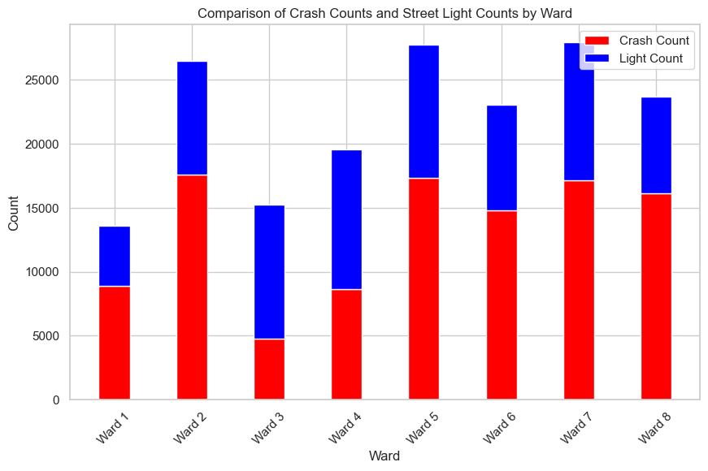

```python
# 将街灯数据中的 'WARD' 列格式转换为 'Ward X' 形式
street_light_gdf['WARD'] = street_light_gdf['WARD'].apply(lambda x: 'Ward ' + str(x))

# 重新计算车祸和路灯数量
crash_counts = crash_gdf.groupby('WARD').size().reset_index(name='crash_count')
light_counts = street_light_gdf.groupby('WARD').size().reset_index(name='light_count')

# 再次合并
ward_data = pd.merge(crash_counts, light_counts, on='WARD', how='inner')  # 确保使用内连接

# 绘制合并后的数据
fig, ax = plt.subplots(figsize=(10, 6))

# 绘制车祸数量
ax.bar(ward_data['WARD'], ward_data['crash_count'], color='red', width=0.4, label='Crash Count', align='center')

# 绘制路灯数量
ax.bar(ward_data['WARD'], ward_data['light_count'], bottom=ward_data['crash_count'], color='blue', width=0.4, label='Light Count', align='center')

ax.set_title('Comparison of Crash Counts and Street Light Counts by Ward')
ax.set_xlabel('Ward')
ax.set_ylabel('Count')
plt.legend()
plt.xticks(rotation=45)
plt.show()
```

This stacked bar graph shows the number of car crashes (in red) and the number of street lights (in blue) in each of the Washington Boroughs (Ward). This graph allows us to analyse the relationship between the frequency of crashes and the number of streetlights in different wards.